# Weather Opens Opportunities in the North, Threatens Central and South

## Thank You

- Jack Carson, Oklahoma Dept of AG-USDA Market News, Oklahoma City, OK
- Heath Dewey, USDA-CO Dept of Ag Market News Service, Greeley, CO
- Lana Hutto, USDA Market News Service, Amarillo, TX
- John Kimbrell, USDA Market News Service, Billings, MT
- Ross Kotewa, USDA-SD Dept of Ag Market News Service, Sioux Falls, SD
- Kim Nettleton, Kansas Department of Agriculture, Manhattan, KS
- Thomas Walthers, USDA NE and USDA WY

## Benchmarks

- Key hay and forage types
- Multi-state & single state

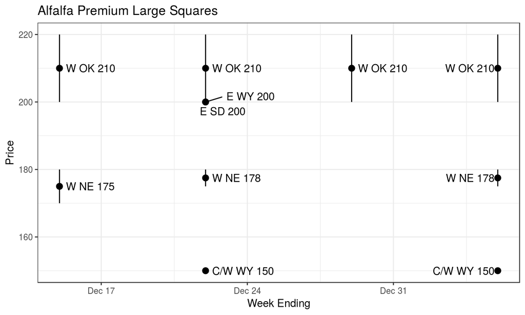

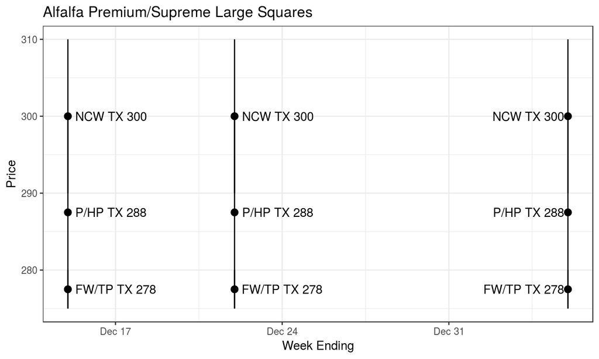

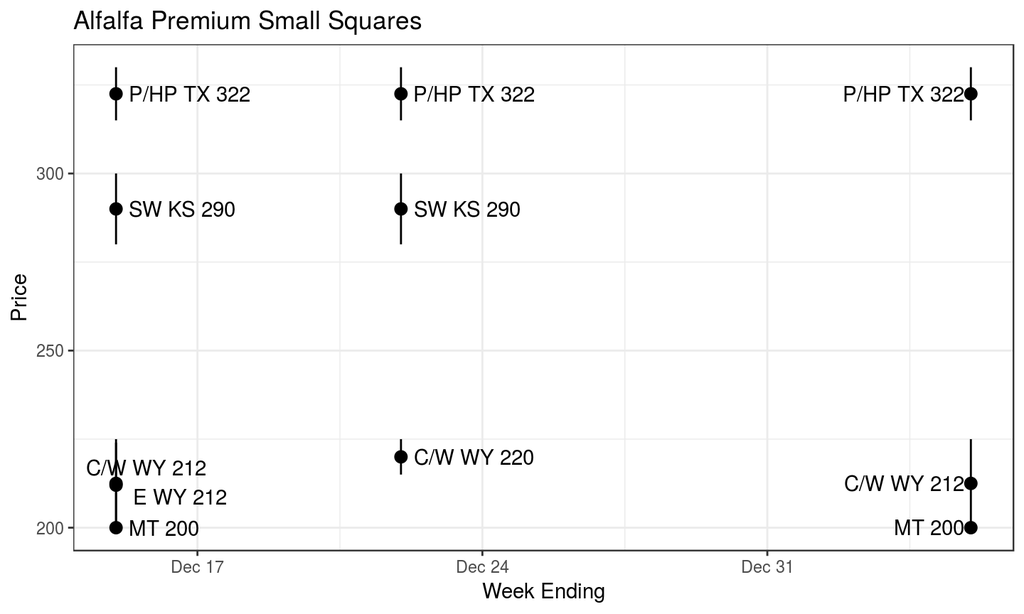

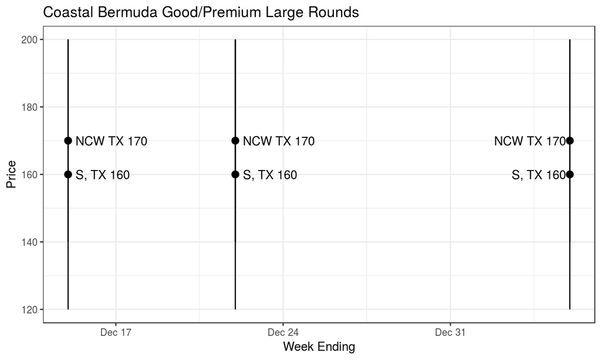

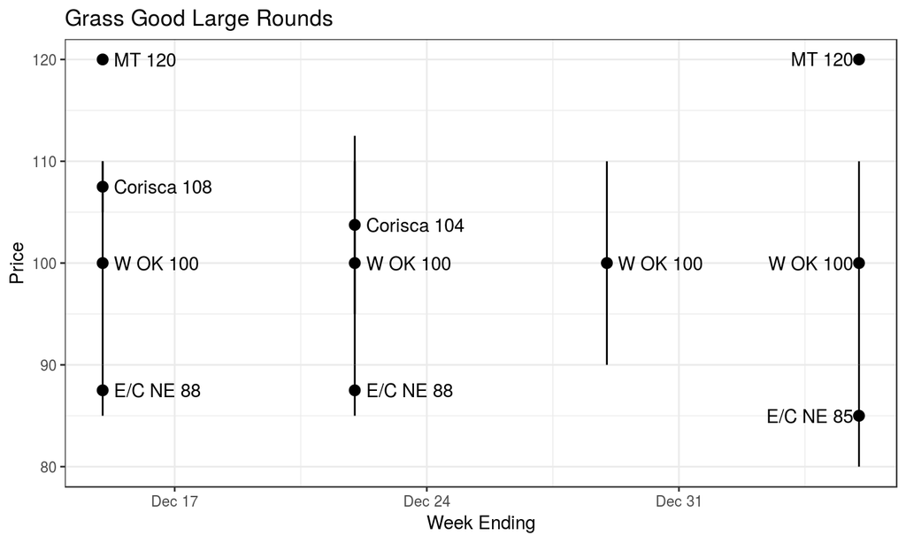

## Higher Prices on the Horizon?

- AMS commentary suggests winter weather may lead to higher prices in the Central and Southern Plains
- Mild weather in Northern Plains leading to lower local demand and prices

## Concerns from South Dakota and Nebraska

Thomas Walthers, reporting on Nebraska

- Halted cornstalk production
- Only increase was +$20 for dehydrated alfalfa pellets in eastern NE
- Milo and corn still being harvested in western NE

Ross Kotewa, Sioux Falls, SD

- Warm weather leading to declining feed yard conditions
- Increase need for straw bedding

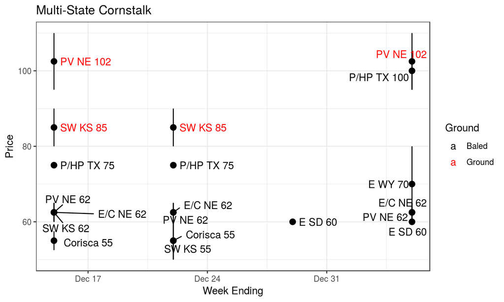

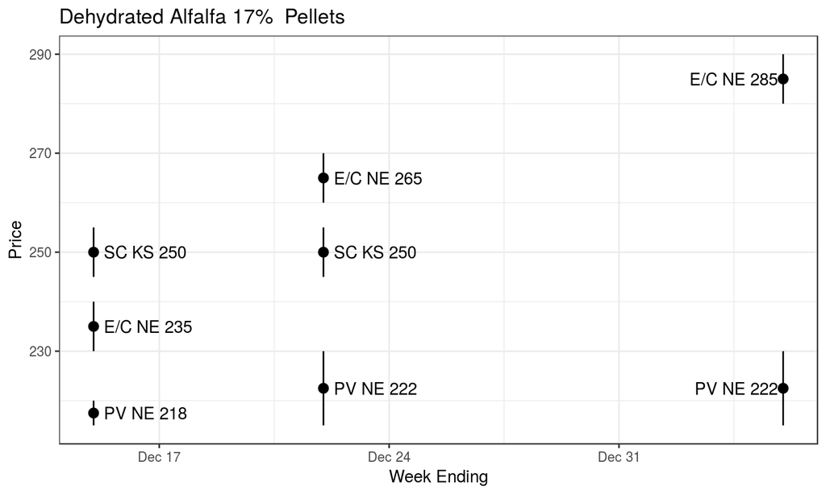

## Montana and Central/Western Wyoming in Good Position

John Kimbrell reports that in Montana:

- Mild weather
- Under-utilization of baled hay
- Out-of-state demand for large squares

Thomas Walthers, reporting on Wyoming

- Large squares for dairies
- Small squares for horse owners

## 8 to 14 Day Temperature

[figure not shown]

## 8 to 14 Day Precipitation

[figure not shown]

## Until Next Week

Visit www.hay.report for archives and resources.